Produced Saturday 30 January 2021

**This is one page of the R Handbook for Epidemiologists, but is being printed as a stand-alone page.**

**You can find the complete handbook on [Github](https://github.com/nsbatra/Epi_R_handbook)**

# Descriptive analysis

## Overview

This tab demonstrates the use of **gtsummary** and **dplyr** to produce descriptive statistics.

1. Browse data: get a quick overview of your dataset using the **skimr** package
2. Summary statistics: mean, median, range, standard deviations, percentiles
3. Frequency / cross-tabs: counts and proportions
4. Statistical tests: t-tests, wilcoxon rank sum, kruskal-wallis and chi-squares
5. Correlations

## Preparation

### Packages

This code chunk shows the loading of packages required for the analyses.

```r
pacman::p_load(rio,          # File import
               here,         # File locator
               skimr,        # get overview of data
               tidyverse,    # data management + ggplot2 graphics,
               gtsummary,    # summary statistics and tests
               corrr         # correlation analayis for numeric variables
               )
```

### Load data

The example dataset used in this section:

- Linelist of individual cases from a simulated epidemic

The dataset is imported using the `import()` function from the *rio* package. See the *page on importing data* for various ways to import data.

```r
# import the linelist
linelist <- rio::import("linelist_cleaned.xlsx")
```

The first 50 rows of the linelist are displayed below.

| case_id | generation | date_infection | date_onset | date_hospitalisation | date_outcome | outcome | gender | age | age_unit | age_years | age_cat | age_cat5 | hospital | lon | lat | infector | source | wt_kg | ht_cm | ct_blood | fever | chills | cough | aches | vomit | temp | time_admission | days_onset_hosp |
| --- | --- | --- | --- | --- | --- | --- | --- | --- | --- | --- | --- | --- | --- | --- | --- | --- | --- | --- | --- | --- | --- | --- | --- | --- | --- | --- | --- | --- |
| 20b688 | 3 |  | 2014-04-15 | 2014-05-06 | 2014-05-14 | Death | m | 14 | years | 14 | 10-14 | 10-14 | Central Hospital | -13.2330769474001 | 8.46002984141364 |  |  | 57.9543370750053 | 166.749418687763 | 21 | no | no | no | no | no | 36.2840110708362 |  | 21 |
| a3c8b8 | 4 | 2014-05-07 | 2014-05-08 | 2014-05-10 | 2014-05-14 | Recover | m | 12 | years | 12 | 10-14 | 10-14 | Port Hospital | -13.2231931914572 | 8.47325128269697 | 2ae019 | other | 72.903315711843 | 133.818602320123 | 22 | no | no | yes | no | no | 37.4817129799808 | 12:25 | 2 |
| 72b905 | 4 | 2014-05-06 | 2014-05-12 | 2014-05-13 |  | Recover | m | 26 | years | 26 | 20-29 | 25-29 | Other | -13.2122631729853 | 8.46838441895748 | 2ae019 | other | 61.3550373807362 | 151.695755303934 | 21 |  |  |  |  |  | 37.1331561923118 |  | 1 |
| 8689b7 | 4 |  | 2014-05-13 | 2014-05-14 | 2014-05-18 | Recover | f | 25 | years | 25 | 20-29 | 25-29 | Missing | -13.2152339775486 | 8.45171855856465 |  |  | 74.9252154987378 | 153.316319514732 | 23 | no | no | yes | no | no | 36.5729378731705 | 13:23 | 1 |
| 11f8ea | 2 |  | 2014-05-16 | 2014-05-18 | 2014-05-30 | Recover | m | 18 | years | 18 | 15-19 | 15-19 | St. Mark's Maternity Hospital (SMMH) | -13.212910703914 | 8.46481700596819 |  |  | 60.8140332121575 | 165.290650391993 | 22 | no | yes | yes | no | no | 36.6132940820539 | 19:49 | 2 |
| 893f25 | 3 | 2014-05-18 | 2014-05-21 | 2014-05-22 | 2014-05-29 | Recover | m | 22 | years | 22 | 20-29 | 20-24 | Military Hospital | -13.2228638912441 | 8.46082377490923 | 11f8ea | other | 73.0392927197671 | 120.122123158907 | 21 | no | no | yes | no | yes | 36.9562671678823 | 15:31 | 1 |
| c4e706 | 5 |  |  | 2014-05-24 | 2014-06-02 |  | m | 6 | years | 6 | 5-9 | 5-9 | Missing | -13.2143394209926 | 8.48932072596067 |  |  | 40.3952926046292 | 108.261883736877 | 21 |  |  |  |  |  | 36.8447226634927 | 13:10 |  |
| e02f66 | 4 | 2014-05-18 |  | 2014-05-25 | 2014-05-31 |  | f | 1 | years | 1 | 0-4 | 0-4 | Port Hospital | -13.2599196027204 | 8.45436259178895 | bd8c0e | other | 18.5860458051297 | 47.4422250141074 | 23 | no | no | yes | no | yes | 37.2397852010363 | 14:27 |  |
| ce9c02 | 5 | 2014-05-27 | 2014-05-27 | 2014-05-29 | 2014-06-17 | Death | m | 13 | years | 13 | 10-14 | 10-14 | Port Hospital | -13.2243703238737 | 8.47024789713924 | 53da57 | other | 65.915405266829 | 166.387318202026 | 22 | no | yes | yes | no | no | 37.2266736491902 | 20:43 | 2 |
| 56d39e | 5 |  | 2014-05-27 | 2014-05-28 |  | Death | f | 27 | years | 27 | 20-29 | 25-29 | St. Mark's Maternity Hospital (SMMH) | -13.2115157489446 | 8.45094401624318 |  |  | 59.7407289858923 | 156.775506829027 | 22 | no | no | no | no | no | 37.2344022830661 | 15:55 | 1 |

[output cut: 40 more lines]

### Clean data

```r
## make sure that age variable is numeric
linelist <- linelist %>%
  mutate(age = as.numeric(age))
```

## Browse data

### Base R

You can use the `summary` function to get information about variables and data sets.

For a numeric variable it will give you the minimum, median, mean and max as well as the 1st quartile (= 25th percentile) and the 3rd quartile (= 75th percentile)

```r
## get information about a numeric variable
summary(linelist$age)
```

```
##    Min. 1st Qu.  Median    Mean 3rd Qu.    Max.    NA's
##    0.00    6.00   13.00   15.09   22.00   67.00      88
```

You can also get an overview of each variable in a whole dataset.

```r
## get information about each variable in a dataset
summary(linelist)
```

```
##    case_id            generation    date_infection         date_onset
##  Length:5889        Min.   : 0.00   Min.   :2012-09-16   Min.   :2014-04-07
##  Class :character   1st Qu.:13.00   1st Qu.:2014-09-06   1st Qu.:2014-09-16
##  Mode  :character   Median :16.00   Median :2014-10-11   Median :2014-10-23
##                     Mean   :16.56   Mean   :2014-10-22   Mean   :2014-11-02
##                     3rd Qu.:20.00   3rd Qu.:2014-12-05   3rd Qu.:2014-12-19
##                     Max.   :37.00   Max.   :2015-04-27   Max.   :2015-04-30
##                                     NA's   :2087         NA's   :248
##  date_hospitalisation  date_outcome          outcome
##  Min.   :2012-09-20   Min.   :2012-10-23   Length:5889
##  1st Qu.:2014-09-19   1st Qu.:2014-09-26   Class :character
##  Median :2014-10-23   Median :2014-11-01   Mode  :character
##  Mean   :2014-11-03   Mean   :2014-11-12
##  3rd Qu.:2014-12-17   3rd Qu.:2014-12-28
##  Max.   :2015-04-30   Max.   :2015-06-04
##                       NA's   :936
##     gender               age          age_unit           age_years
##  Length:5889        Min.   : 0.00   Length:5889        Min.   : 0.00
##  Class :character   1st Qu.: 6.00   Class :character   1st Qu.: 6.00
##  Mode  :character   Median :13.00   Mode  :character   Median :13.00
##                     Mean   :15.09                      Mean   :15.04
##                     3rd Qu.:22.00                      3rd Qu.:22.00
##                     Max.   :67.00                      Max.   :67.00
##                     NA's   :88                         NA's   :88
##     age_cat        age_cat5      hospital              lon
##  5-9    :1148   5-9    :1148   Length:5889        Min.   :-13.27
##  20-29  :1091   0-4    :1081   Class :character   1st Qu.:-13.25
##  0-4    :1081   10-14  : 971   Mode  :character   Median :-13.23
##  10-14  : 971   15-19  : 837                      Mean   :-13.23
##  15-19  : 837   20-24  : 600                      3rd Qu.:-13.22
##  (Other): 673   (Other):1164                      Max.   :-13.21
##  NA's   :  88   NA's   :  88
##       lat          infector            source              wt_kg
##  Min.   :8.446   Length:5889        Length:5889        Min.   :-15.97
##  1st Qu.:8.461   Class :character   Class :character   1st Qu.: 41.30
##  Median :8.469   Mode  :character   Mode  :character   Median : 54.37
##  Mean   :8.470                                         Mean   : 52.75
##  3rd Qu.:8.480                                         3rd Qu.: 65.73
##  Max.   :8.492                                         Max.   :109.51
##
```

[output cut: 9 more lines]

```
##  Length:5889        Length:5889        Length:5889        Min.   :35.28
##  Class :character   Class :character   Class :character   1st Qu.:38.17
##  Mode  :character   Mode  :character   Mode  :character   Median :38.83
##                                                           Mean   :38.56
##                                                           3rd Qu.:39.24
##                                                           Max.   :40.76
##                                                           NA's   :137
##  time_admission     days_onset_hosp
##  Length:5889        Min.   : 0.00
##  Class :character   1st Qu.: 1.00
##  Mode  :character   Median : 1.00
##                     Mean   : 2.06
##                     3rd Qu.: 3.00
##                     Max.   :22.00
##                     NA's   :248
```

### `skimr` package

Using the `skimr` package you can get a more detailed overview of each of the variables in your dataset.

```r
## get information about each variable in a dataset
skim(linelist)
```

Data summary

| Name | linelist |
| --- | --- |
| Number of rows | 5889 |
| Number of columns | 29 |
| _______________________ |  |
| Column type frequency: |  |
| character | 13 |
| Date | 4 |
| factor | 2 |
| numeric | 10 |
| ________________________ |  |
| Group variables | None |

**Variable type: character**

| skim_variable | n_missing | complete_rate | min | max | empty | n_unique | whitespace |
| --- | --- | --- | --- | --- | --- | --- | --- |
| case_id | 0 | 1.00 | 6 | 6 | 0 | 5888 | 0 |
| outcome | 1323 | 0.78 | 5 | 7 | 0 | 2 | 0 |
| gender | 283 | 0.95 | 1 | 1 | 0 | 2 | 0 |
| age_unit | 0 | 1.00 | 5 | 6 | 0 | 2 | 0 |
| hospital | 0 | 1.00 | 5 | 36 | 0 | 6 | 0 |
| infector | 2088 | 0.65 | 6 | 6 | 0 | 2697 | 0 |
| source | 2088 | 0.65 | 5 | 7 | 0 | 2 | 0 |
| fever | 237 | 0.96 | 2 | 3 | 0 | 2 | 0 |
| chills | 237 | 0.96 | 2 | 3 | 0 | 2 | 0 |
| cough | 237 | 0.96 | 2 | 3 | 0 | 2 | 0 |
| aches | 237 | 0.96 | 2 | 3 | 0 | 2 | 0 |
| vomit | 237 | 0.96 | 2 | 3 | 0 | 2 | 0 |
| time_admission | 730 | 0.88 | 5 | 5 | 0 | 1081 | 0 |

**Variable type: Date**

| skim_variable | n_missing | complete_rate | min | max | median | n_unique |
| --- | --- | --- | --- | --- | --- | --- |
| date_infection | 2087 | 0.65 | 2012-09-16 | 2015-04-27 | 2014-10-11 | 360 |
| date_onset | 248 | 0.96 | 2014-04-07 | 2015-04-30 | 2014-10-23 | 365 |
| date_hospitalisation | 0 | 1.00 | 2012-09-20 | 2015-04-30 | 2014-10-23 | 364 |
| date_outcome | 936 | 0.84 | 2012-10-23 | 2015-06-04 | 2014-11-01 | 372 |

**Variable type: factor**

| skim_variable | n_missing | complete_rate | ordered | n_unique | top_counts |
| --- | --- | --- | --- | --- | --- |
| age_cat | 88 | 0.99 | FALSE | 7 | 5-9: 1148, 20-: 1091, 0-4: 1081, 10-: 971 |
| age_cat5 | 88 | 0.99 | FALSE | 14 | 5-9: 1148, 0-4: 1081, 10-: 971, 15-: 837 |

**Variable type: numeric**

| skim_variable | n_missing | complete_rate | mean | sd | p0 | p25 | p50 | p75 | p100 | hist |
| --- | --- | --- | --- | --- | --- | --- | --- | --- | --- | --- |
| generation | 0 | 1.00 | 16.56 | 5.79 | 0.00 | 13.00 | 16.00 | 20.00 | 37.00 | ▁▆▇▂▁ |
| age | 88 | 0.99 | 15.09 | 11.23 | 0.00 | 6.00 | 13.00 | 22.00 | 67.00 | ▇▅▂▁▁ |
| age_years | 88 | 0.99 | 15.04 | 11.26 | 0.00 | 6.00 | 13.00 | 22.00 | 67.00 | ▇▅▂▁▁ |
| lon | 0 | 1.00 | -13.23 | 0.02 | -13.27 | -13.25 | -13.23 | -13.22 | -13.21 | ▅▃▃▆▇ |
| lat | 0 | 1.00 | 8.47 | 0.01 | 8.45 | 8.46 | 8.47 | 8.48 | 8.49 | ▅▇▇▇▆ |
| wt_kg | 0 | 1.00 | 52.75 | 18.38 | -15.97 | 41.30 | 54.37 | 65.73 | 109.51 | ▁▂▇▆▁ |
| ht_cm | 0 | 1.00 | 123.98 | 48.90 | 6.78 | 90.67 | 127.66 | 156.98 | 282.20 | ▂▅▇▃▁ |
| ct_blood | 0 | 1.00 | 21.19 | 1.68 | 16.00 | 20.00 | 22.00 | 22.00 | 25.00 | ▁▃▅▇▁ |
| temp | 137 | 0.98 | 38.56 | 0.99 | 35.28 | 38.17 | 38.83 | 39.24 | 40.76 | ▁▂▂▇▁ |
| days_onset_hosp | 248 | 0.96 | 2.06 | 2.27 | 0.00 | 1.00 | 1.00 | 3.00 | 22.00 | ▇▁▁▁▁ |

## Summary Statistics

### `gtsummary` package

Using `gtsummary` you can create a table with different summary statistics, for example mean, median, range, standard deviation and percentiles. You can also show these all in one table.

#### **Mean**

Note that this automatically excludes all missing values. If missing values are not excluded, the returned value will be NA (missing). The number of missing values is seen in the Unknown column.

```r
linelist %>%
  ## only keep variable of interest
  select(age) %>%
  ## create summary table with mean
  tbl_summary(statistic = age ~ "{mean}")
```

| **Characteristic** | **N = 5,889**<sup>1</sup> |
| --- | --- |
| age | 15 |
| Unknown | 88 |

<sup>*1*</sup> Mean

#### **Median**

Note that this automatically excludes all missing values. If missing values are not excluded, the returned value will be NA (missing). The number of missing values is seen in the Unknown column).

```r
linelist %>%
  ## only keep variable of interest
  select(age) %>%
  ## create summary table with median
  tbl_summary(statistic = age ~ "{median}")
```

| **Characteristic** | **N = 5,889**<sup>1</sup> |
| --- | --- |
| age | 13 |
| Unknown | 88 |

<sup>*1*</sup> Median

#### **Range**

The range here is the minimum and maximum values for the variable. (see *percentiles* for interquartile range) Note that this automatically excludes all missing values. If missing values are not excluded, the returned value will be NA (missing). The number of missing values is seen in the Unknown column).

```r
linelist %>%
  ## only keep variable of interest
  select(age) %>%
  ## create summary table with range
  tbl_summary(statistic = age ~ "{min}, {max}")
```

| **Characteristic** | **N = 5,889**<sup>1</sup> |
| --- | --- |
| age | 0, 67 |
| Unknown | 88 |

<sup>*1*</sup> Range

#### **Standard deviation**

Note that this automatically excludes all missing values. If missing values are not excluded, the returned value will be NA (missing). The number of missing values is seen in the Unknown column).

```r
linelist %>%
  ## only keep variable of interest
  select(age) %>%
  ## create summary table with standard deviation
  tbl_summary(statistic = age ~ "{sd}")
```

| **Characteristic** | **N = 5,889**<sup>1</sup> |
| --- | --- |
| age | 11 |
| Unknown | 88 |

<sup>*1*</sup> SD

#### **Percentile**

To return percentiles you can type in one value that you would like, or you can type in multiple (e.g. to return the interquartile range).

Note that this automatically excludes all missing values. If missing values are not excluded, the returned value will be NA (missing). The number of missing values is seen in the Unknown column).

```r
linelist %>%
  ## only keep variable of interest
  select(age) %>%
  ## create summary table with interquartile range
  tbl_summary(statistic = age ~ "{p25}, {p75}")
```

| **Characteristic** | **N = 5,889**<sup>1</sup> |
| --- | --- |
| age | 6, 22 |
| Unknown | 88 |

<sup>*1*</sup> IQR

#### **Combined table**

You can combine all of the previously shown elements in one table by choosing which statistics you want to show. To do this you need to tell the function that you want to get a table back by entering the type as “continuous2”.

Note that this automatically excludes all missing values. If missing values are not excluded, the returned value will be NA (missing). The number of missing values is seen in the Unknown column).

```r
linelist %>%
  ## only keep variable of interest
  select(age) %>%
  ## create summary table with interquartile range
  tbl_summary(
    ## tell the function you want to get multiple statistics back
    type = age ~ "continuous2",
    ## define which statistics you want to get back
    statistic = age ~ c(
    "{mean} ({sd})",
    "{median} ({p25}, {p75})",
    "{min}, {max}")
    )
```

| **Characteristic** | **N = 5,889** |
| --- | --- |
| age |  |
| Mean (SD) | 15 (11) |
| Median (IQR) | 13 (6, 22) |
| Range | 0, 67 |
| Unknown | 88 |

### `dplyr` package

You can also use `dplyr` to create a table with different summary statistics, for example mean, median, range, standard deviation and percentiles. You can also show these all in one table. The difference with using dplyr is that the output is not automatically formatted as nicely as with `gtsummary`

#### **Mean**

Note the argument `na.rm = TRUE`, which removes missing values from the calculation.  
If missing values are not excluded, the returned value will be NA (missing).

```r
linelist %>%
  ## get the mean value of age while excluding missings
  summarise(mean = mean(age, na.rm = TRUE))
```

```
##       mean
## 1 15.09205
```

#### **Median**

Note the argument `na.rm = TRUE`, which removes missing values from the calculation.  
If missing values are not excluded, the returned value will be NA (missing).

```r
linelist %>%
  ## get the median value of age while excluding missings
  summarise(median = median(age, na.rm = TRUE))
```

```
##   median
## 1     13
```

#### **Range**

Note the argument `na.rm = TRUE`, which removes missing values from the calculation.  
If missing values are not excluded, the returned value will be NA (missing).

```r
linelist %>%
  ## get the range value of age while excluding missings
  summarise(range = range(age, na.rm = TRUE))
```

```
##   range
## 1     0
## 2    67
```

#### **Standard Deviation**

Note the argument `na.rm = TRUE`, which removes missing values from the calculation.  
If missing values are not excluded, the returned value will be NA (missing).

```r
linelist %>%
  ## get the range value of age while excluding missings
  summarise(sd = sd(age, na.rm = TRUE))
```

```
##         sd
## 1 11.23393
```

#### **Percentile**

To return percentiles you can type in one value that you would like, or you can type in multiple (e.g. to return the interquartile range).

Note the argument `na.rm = TRUE`, which removes missing values from the calculation.  
If missing values are not excluded, the returned value will be NA (missing).

```r
linelist %>%
  ## get the default percentile values of age while excluding missings
  ## these are 0%,  25%,  50%,  75%, 100%
  summarise(percentiles = quantile(age, na.rm = TRUE))
```

```
##   percentiles
## 1           0
## 2           6
## 3          13
## 4          22
## 5          67
```

```r
linelist %>%
  ## get specified percentile values of age while excluding missings
  ## these are 0%, 50%,  75%, 98%
  summarise(percentiles = quantile(age,
                                   probs = c(.05, 0.5, 0.75, 0.98),
                                   na.rm=TRUE))
```

```
##   percentiles
## 1           1
## 2          13
## 3          22
## 4          43
```

#### **Combined table**

You can combine all of the previously shown elements in one table by choosing which statistics you want to show. In dplyr you will need to use the `str_c` function from **stringr** to combine outputs for the IQR and the range in to one cell, separated by a comma.

Note that this automatically excludes all missing values. If missing values are not excluded, the returned value will be NA (missing). The number of missing values is seen in the Unknown column).

```r
linelist %>%
  summarise(
    ## get the mean
    mean = mean(age, na.rm = TRUE),
    ## get the standard deviation
    SD = sd(age, na.rm = TRUE),
    ## get the median
    median = median(age, na.rm = TRUE),
    ## collapse the IQR separated by a comma
    IQR = str_c(
      quantile(age, probs = c(0.25, 0.75), na.rm = TRUE),
      collapse = ", "
      ),
    ## collapse the range separated by a comma
    Range = str_c(
      range(age, na.rm = TRUE),
      collapse = ", "
    )
  )
```

```
##       mean       SD median   IQR Range
## 1 15.09205 11.23393     13 6, 22 0, 67
```

## Frequency/cross-tabs

### `gtsummary` package

TODO: Note that percentages are calculated without missings

Using `gtsummary` you can create a table with different counts and proportions for variables with two or more categories, as well as grouping by another variable.

#### **One way table**

To produce the counts of a single variable we can use the `tbl_summary` function. Note that here, the fever variable is yes/no (dichotomous) and `tbl_summary` automatically only presents the “yes” row. To show all levels you could use the type argument to choose categorical, e.g. `tbl_summary(type = fever ~ "categorical")`.

```r
linelist %>%
  ## only keep the variable interested in
  select(fever) %>%
  ## produce summary table
  tbl_summary()
```

| **Characteristic** | **N = 5,889**<sup>1</sup> |
| --- | --- |
| fever | 4,517 (80%) |
| Unknown | 237 |

<sup>*1*</sup> n (%)

#### **Multiple variable one way table**

You can also show multiple variables below each other simply by adding them to `select`.

```r
linelist %>%
  ## only keep the variable interested in
  select(fever, gender) %>%
  ## produce summary table
  tbl_summary()
```

| **Characteristic** | **N = 5,889**<sup>1</sup> |
| --- | --- |
| fever | 4,517 (80%) |
| Unknown | 237 |
| gender |  |
| f | 2,805 (50%) |
| m | 2,801 (50%) |
| Unknown | 283 |

<sup>*1*</sup> n (%)

#### **Two way table**

There are two options to produce a two-by-two table (i.e. comparing two variables). One option is to use `tbl_cross`, however this function only accepts two variables at once. The option below with `tbl_summary` allows more variables.

```r
linelist %>%
  ## only keep the variable interested in
  select(fever, outcome, gender) %>%
  ## produce summary table stratified by gender
  tbl_summary(by = gender) %>%
  ## add a column for the totals
  add_overall()
```

| **Characteristic** | **Overall**, N = 5,606<sup>1</sup> | **f**, N = 2,805<sup>1</sup> | **m**, N = 2,801<sup>1</sup> |
| --- | --- | --- | --- |
| fever | 4,293 (80%) | 2,145 (80%) | 2,148 (80%) |
| Unknown | 229 | 107 | 122 |
| outcome |  |  |  |
| Death | 2,460 (56%) | 1,233 (57%) | 1,227 (56%) |
| Recover | 1,901 (44%) | 949 (43%) | 952 (44%) |
| Unknown | 1,245 | 623 | 622 |

<sup>*1*</sup> n (%)

#### **Three way table**

Producing counts based on three variables (adding a stratifier).

```r
## TODO: add stratified tables when available

# table_3vars <- table(linelist$fever, linelist$gender, linelist$outcome)
#
# ftable(table_3vars)
```

### `dplyr` package

Creating cross tabulations with dplyr is less straightforward, as this does not fit within the **tidyverse** dataset structure. It is still useful to demonstrate though as the data produced can be used for plotting *reference ggplot section*. Another option is to use the **janitor** package [`tabyl` function](http://sfirke.github.io/janitor/reference/tabyl.html).

#### **One way table**

Producing counts and proportions for a single variable. To see how to do this for multiple variables - *reference for-loop section*.

```r
linelist %>%
  ## count the variable of interest
  count(fever) %>%
  ## calculate proportion
  mutate(percentage = n / sum(n) * 100)
```

```
##   fever    n percentage
## 1    no 1135  19.273221
## 2   yes 4517  76.702326
## 3  <NA>  237   4.024452
```

#### **Two way table**

Producing counts and proportions based on a grouping variable. Here we use the **dplyr** `group_by` function, for more information see the *reference grouping and aggregating section*. You can calculate the percentages of the total by using `ungroup()` after `count(...)`.

Note that it is possible to change the bellow table to wide format, making it more like a two-by-two (cross tabulation), using the **tidyr** `pivot_wider` function. This would be done by adding this to the end of the code blow: `pivot_wider(names_from = gender, values_from = c(n, percentage))` For more information see the *reference pivot section*.

```r
linelist %>%
  ## do everything by gender
  group_by(gender) %>%
  ## count the variable of interest
  count(fever) %>%
  ## calculate proportion
  ## note that the denominator here is the sum of each gender
  mutate(percentage = n / sum(n) * 100)
```

```
## # A tibble: 9 x 4
## # Groups:   gender [3]
##   gender fever     n percentage
##   <chr>  <chr> <int>      <dbl>
## 1 f      no      553      19.7
## 2 f      yes    2145      76.5
## 3 f      <NA>    107       3.81
## 4 m      no      531      19.0
## 5 m      yes    2148      76.7
## 6 m      <NA>    122       4.36
## 7 <NA>   no       51      18.0
## 8 <NA>   yes     224      79.2
## 9 <NA>   <NA>      8       2.83
```

#### **Three way table**

Producing counts based on three variables (adding a stratifier).

```r
linelist %>%
  ## do everything by gender and outcome
  group_by(gender, outcome) %>%
  ## count the variable of interest
  count(fever) %>%
  ## calculate the proportion
  ## note that the denominator here is the sum of each group combination
  mutate(percentage = n / sum(n) * 100)
```

```
## # A tibble: 27 x 5
## # Groups:   gender, outcome [9]
##    gender outcome fever     n percentage
##    <chr>  <chr>   <chr> <int>      <dbl>
##  1 f      Death   no      239      19.4
##  2 f      Death   yes     941      76.3
##  3 f      Death   <NA>     53       4.30
##  4 f      Recover no      188      19.8
##  5 f      Recover yes     725      76.4
##  6 f      Recover <NA>     36       3.79
##  7 f      <NA>    no      126      20.2
##  8 f      <NA>    yes     479      76.9
##  9 f      <NA>    <NA>     18       2.89
## 10 m      Death   no      235      19.2
## # ... with 17 more rows
```

## Statistical tests

### `gtsummary` package

Performing statistical tests of comparison with `tbl_summary` is done by using `add_p` function and specifying which test to use. It is possible to get p-values corrected for multiple testing by using the `add_q` function.

#### T-tests

Compare the difference in means for a continuous variable in two groups. For example compare the mean age by patient outcome.

```r
linelist %>%
  ## only keep variables of interested
  select(age, outcome) %>%
  ## produce summary table
  tbl_summary(
    ## specify what statistic want to show
    statistic = age ~ "{mean} ({sd})",
    ## specify the grouping variable
    by = outcome) %>%
  ## specify what test want to perform
  add_p(age ~ "t.test")
```

| **Characteristic** | **Death**, N = 2,582<sup>1</sup> | **Recover**, N = 1,984<sup>1</sup> | **p-value**<sup>2</sup> |
| --- | --- | --- | --- |
| age | 15 (11) | 15 (11) | 0.4 |
| Unknown | 34 | 27 |  |

<sup>*1*</sup> Mean (SD) <sup>*2*</sup> Welch Two Sample t-test

#### Wilcoxon rank sum test

Compare the distribution of a continuous variable in two groups. The default is to use the Wilcoxon rank sum test and the median (IQR) when comparing two groups. However for non-normally distributed data or comparing multiple groups, the Kruskal-wallis test is more appropriate.

```r
linelist %>%
  ## only keep variables of interested
  select(age, outcome) %>%
  ## produce summary table
  tbl_summary(
    ## specify what statistic want to show (default so could remove)
    statistic = age ~ "{median} ({p25}, {p75})",
    ## specify the grouping variable
    by = outcome) %>%
  ## specify what test want to perform (default so could leave brackets empty)
  add_p(age ~ "wilcox.test")
```

| **Characteristic** | **Death**, N = 2,582<sup>1</sup> | **Recover**, N = 1,984<sup>1</sup> | **p-value**<sup>2</sup> |
| --- | --- | --- | --- |
| age | 13 (6, 22) | 13 (6, 21) | 0.6 |
| Unknown | 34 | 27 |  |

<sup>*1*</sup> Median (IQR) <sup>*2*</sup> Wilcoxon rank sum test

#### Kruskal-wallis test

Compare the distribution of a continuous variable in two or more groups, regardless of whether the data is normally distributed.

```r
linelist %>%
  ## only keep variables of interested
  select(age, outcome) %>%
  ## produce summary table
  tbl_summary(
    ## specify what statistic want to show (default so could remove)
    statistic = age ~ "{median} ({p25}, {p75})",
    ## specify the grouping variable
    by = outcome) %>%
  ## specify what test want to perform
  add_p(age ~ "kruskal.test")
```

| **Characteristic** | **Death**, N = 2,582<sup>1</sup> | **Recover**, N = 1,984<sup>1</sup> | **p-value**<sup>2</sup> |
| --- | --- | --- | --- |
| age | 13 (6, 22) | 13 (6, 21) | 0.6 |
| Unknown | 34 | 27 |  |

<sup>*1*</sup> Median (IQR) <sup>*2*</sup> Kruskal-Wallis rank sum test

#### Chi-squared test

Compare the proportions of a categorical variable in two groups. The default is to perform a chi-squared test of independence with continuity correction, but if any expected call count is below 5 then a Fisher’s exact test is used.

```r
linelist %>%
  ## only keep variables of interested
  select(gender, outcome) %>%
  ## produce summary table
  tbl_summary(
    ## specify the grouping variable
    by = outcome
  ) %>%
  ## specify what test want to perform
  add_p()
```

| **Characteristic** | **Death**, N = 2,582<sup>1</sup> | **Recover**, N = 1,984<sup>1</sup> | **p-value**<sup>2</sup> |
| --- | --- | --- | --- |
| gender |  |  | 0.9 |
| f | 1,233 (50%) | 949 (50%) |  |
| m | 1,227 (50%) | 952 (50%) |  |
| Unknown | 122 | 83 |  |

<sup>*1*</sup> n (%) <sup>*2*</sup> Pearson's Chi-squared test

### `dplyr` package

Performing statistical tests in `dplyr` alone is very dense, again because it does not fit within the tidy-data framework. It requires using `purrr` to create a list of dataframes for each of the subgroups you want to compare. An easier alternative may be the `rstatix` package.

#### T-tests

```r
linelist %>%
  ## only keep variables of interest
  select(age, outcome) %>%
  ## drop those missing outcome
  filter(!is.na(outcome)) %>%
  ## specify the grouping variable
  group_by(outcome) %>%
  ## create a subset of data for each group (as a list)
  nest() %>%
  ## spread in to wide format
  pivot_wider(names_from = outcome, values_from = data) %>%
  mutate(
    ## calculate the mean age for the death group
    Death_mean = map(Death, ~mean(.x$age, na.rm = TRUE)),
    ## calculate the sd among dead
    Death_sd = map(Death, ~sd(.x$age, na.rm = TRUE)),
    ## calculate the mean age for the recover group
    Recover_mean = map(Recover, ~mean(.x$age, na.rm = TRUE)),
    ## calculate the sd among recovered
    Recover_sd = map(Recover, ~sd(.x$age, na.rm = TRUE)),
    ## using both grouped data sets compare mean age with a t-test
    ## keep only the p.value
    t_test = map2(Death, Recover, ~t.test(.x$age, .y$age)$p.value)
  ) %>%
  ## drop datasets
  select(-Death, -Recover) %>%
  ## return a dataset with the medians and p.value (drop missing)
  unnest(cols = everything())
```

```
## # A tibble: 1 x 5
##   Death_mean Death_sd Recover_mean Recover_sd t_test
##        <dbl>    <dbl>        <dbl>      <dbl>  <dbl>
## 1       15.1     11.3         14.8       11.0  0.445
```

#### Wilcoxon rank sum test

```r
linelist %>%
  ## only keep variables of interest
  select(age, outcome) %>%
  ## drop those missing outcome
  filter(!is.na(outcome)) %>%
  ## specify the grouping variable
  group_by(outcome) %>%
  ## create a subset of data for each group (as a list)
  nest() %>%
  ## spread in to wide format
  pivot_wider(names_from = outcome, values_from = data) %>%
  mutate(
    ## calculate the median age for the death group
    Death_median = map(Death, ~median(.x$age, na.rm = TRUE)),
    ## calculate the sd among dead
    Death_iqr = map(Death, ~str_c(
      quantile(.x$age, probs = c(0.25, 0.75), na.rm = TRUE),
      collapse = ", "
      )),
    ## calculate the median age for the recover group
    Recover_median = map(Recover, ~median(.x$age, na.rm = TRUE)),
    ## calculate the sd among recovered
    Recover_iqr = map(Recover, ~str_c(
      quantile(.x$age, probs = c(0.25, 0.75), na.rm = TRUE),
      collapse = ", "
      )),
    ## using both grouped data sets compare age distribution with a wilcox test
    ## keep only the p.value
    wilcox = map2(Death, Recover, ~wilcox.test(.x$age, .y$age)$p.value)
  ) %>%
  ## drop datasets
  select(-Death, -Recover) %>%
  ## return a dataset with the medians and p.value (drop missing)
  unnest(cols = everything())
```

```
## # A tibble: 1 x 5
##   Death_median Death_iqr Recover_median Recover_iqr wilcox
##          <dbl> <chr>              <dbl> <chr>        <dbl>
## 1           13 6, 22                 13 6, 21        0.608
```

#### Kruskal-wallis test

```r
linelist %>%
  ## only keep variables of interest
  select(age, outcome) %>%
  ## drop those missing outcome
  filter(!is.na(outcome)) %>%
  ## specify the grouping variable
  group_by(outcome) %>%
  ## create a subset of data for each group (as a list)
  nest() %>%
  ## spread in to wide format
  pivot_wider(names_from = outcome, values_from = data) %>%
  mutate(
    ## calculate the median age for the death group
    Death_median = map(Death, ~median(.x$age, na.rm = TRUE)),
    ## calculate the sd among dead
    Death_iqr = map(Death, ~str_c(
      quantile(.x$age, probs = c(0.25, 0.75), na.rm = TRUE),
      collapse = ", "
      )),
    ## calculate the median age for the recover group
    Recover_median = map(Recover, ~median(.x$age, na.rm = TRUE)),
    ## calculate the sd among recovered
    Recover_iqr = map(Recover, ~str_c(
      quantile(.x$age, probs = c(0.25, 0.75), na.rm = TRUE),
      collapse = ", "
      )),
    ## using the original data set compare age distribution with a kruskal test
    ## keep only the p.value
    kruskal = kruskal.test(linelist$age, linelist$outcome)$p.value
  ) %>%
  ## drop datasets
  select(-Death, -Recover) %>%
  ## return a dataset with the medians and p.value (drop missing)
  unnest(cols = everything())
```

```
## # A tibble: 1 x 5
##   Death_median Death_iqr Recover_median Recover_iqr kruskal
##          <dbl> <chr>              <dbl> <chr>         <dbl>
## 1           13 6, 22                 13 6, 21         0.608
```

#### Chi-squared test

```r
linelist %>%
  ## do everything by gender
  group_by(outcome) %>%
  ## count the variable of interest
  count(gender) %>%
  ## calculate proportion
  ## note that the denominator here is the sum of each gender
  mutate(percentage = n / sum(n) * 100) %>%
  pivot_wider(names_from = outcome, values_from = c(n, percentage)) %>%
  filter(!is.na(gender)) %>%
  mutate(pval = chisq.test(linelist$gender, linelist$outcome)$p.value)
```

```
## # A tibble: 2 x 8
##   gender n_Death n_Recover  n_NA percentage_Death percentage_Reco~ percentage_NA
##   <chr>    <int>     <int> <int>            <dbl>            <dbl>         <dbl>
## 1 f         1233       949   623             47.8             47.8          47.1
## 2 m         1227       952   622             47.5             48.0          47.0
## # ... with 1 more variable: pval <dbl>
```

### `base` package

You can also just use the `base` functions to produce the results of statistical tests. The outputs of these are however usually lists, and so are harder to manipulate.

#### T-tests

```r
## compare mean age by outcome group with a t-test
t.test(age ~ outcome, data = linelist)
```

```
##
##  Welch Two Sample t-test
##
## data:  age by outcome
## t = 0.76363, df = 4261.3, p-value = 0.4451
## alternative hypothesis: true difference in means is not equal to 0
## 95 percent confidence interval:
##  -0.4007016  0.9120010
## sample estimates:
##   mean in group Death mean in group Recover
##              15.07732              14.82167
```

#### Wilcoxon rank sum test

```r
## compare age distribution by outcome group with a wilcox test
wilcox.test(age ~ outcome, data = linelist)
```

```
##
##  Wilcoxon rank sum test with continuity correction
##
## data:  age by outcome
## W = 2515431, p-value = 0.6075
## alternative hypothesis: true location shift is not equal to 0
```

#### Kruskal-wallis test

```r
## compare age distribution by outcome group with a kruskal-wallis test
kruskal.test(age ~ outcome, linelist)
```

```
##
##  Kruskal-Wallis rank sum test
##
## data:  age by outcome
## Kruskal-Wallis chi-squared = 0.26378, df = 1, p-value = 0.6075
```

#### Chi-squared test

```r
## compare the proportions in each group with a chi-squared test
chisq.test(linelist$gender, linelist$outcome)
```

```
##
##  Pearson's Chi-squared test with Yates' continuity correction
##
## data:  linelist$gender and linelist$outcome
## X-squared = 0.010203, df = 1, p-value = 0.9195
```

## Correlations

Correlation between numeric variables can be investigated using the tidyverse `corrr` package. It allows you to compute correlations using Pearson, Kendall tau or Spearman rho. The package creates a table and also has a function to automatically plot the values.

```r
correlation_tab <- linelist %>%
  ## pick the numeric variables of interest
  select(generation, age, ct_blood, days_onset_hosp, wt_kg, ht_cm) %>%
  ## create correlation table (using default pearson)
  correlate()

## remove duplicate entries (the table is mirrored)
correlation_tab <- correlation_tab %>%
  shave()


## view correlation table
correlation_tab
```

```
## # A tibble: 6 x 7
##   term            generation     age ct_blood days_onset_hosp  wt_kg ht_cm
##   <chr>                <dbl>   <dbl>    <dbl>           <dbl>  <dbl> <dbl>
## 1 generation         NA      NA      NA               NA      NA        NA
## 2 age                -0.0144 NA      NA               NA      NA        NA
## 3 ct_blood            0.184  -0.0108 NA               NA      NA        NA
## 4 days_onset_hosp    -0.289  -0.0147 -0.600           NA      NA        NA
## 5 wt_kg              -0.0153  0.840  -0.00763         -0.0153 NA        NA
## 6 ht_cm              -0.0150  0.882  -0.00907         -0.0121  0.885    NA
```

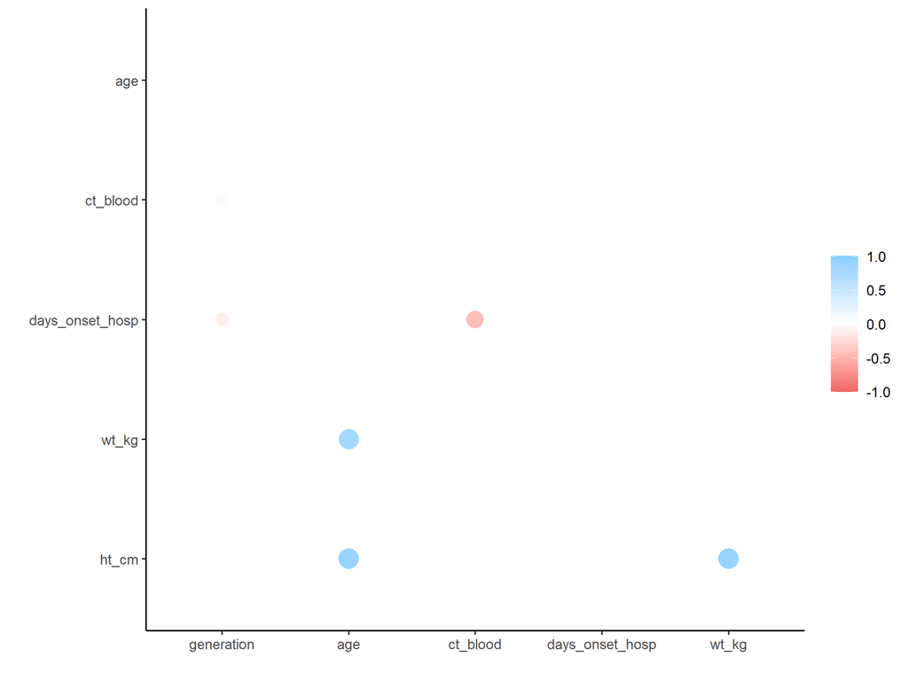

```r
## plot correlations
rplot(correlation_tab)
```

## Resources

Much of the information in this page is adapted from these resources and vignettes online:

[gtsummary](http://www.danieldsjoberg.com/gtsummary/articles/tbl_summary.html) [dplyr](https://dplyr.tidyverse.org/articles/grouping.html) [corrr](https://corrr.tidymodels.org/articles/using-corrr.html) [sthda correlation](http://www.sthda.com/english/wiki/correlation-test-between-two-variables-in-r)